# Python 與機器學習 - 迴歸問題

## 郭耀仁

## 迴歸問題有哪些？

- 利用月收入來核定信用卡額度
- 利用坪數、房間數來預測房價
- 利用每日最高氣溫來預測飲料店的冰紅茶銷量
- ...etc.

## 氣溫與冰紅茶銷量

- 利用每日最高氣溫來預測飲料店的冰紅茶銷量
- 先畫一個散佈圖

Data source: [世界第一簡單統計學](http://www.books.com.tw/products/0010695099)

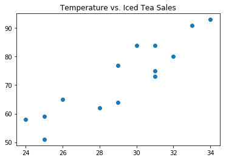

```python
import matplotlib.pyplot as plt

temperature = [29, 28, 34, 31, 25, 29, 32, 31, 24, 33, 25, 31, 26, 30]
iced_tea_sales = [77, 62, 93, 84, 59, 64, 80, 75, 58, 91, 51, 73, 65, 84]
plt.scatter(x = temperature, y = iced_tea_sales)
plt.title("Temperature vs. Iced Tea Sales")
plt.show()
```

## 氣溫與冰紅茶銷量（2）

- 真實的氣溫與冰紅茶銷量的關係：

$$y = f(x)$$

- 但沒有人知道 $f$ 到底是什麼，我們只能假設氣溫與冰紅茶銷量的關係是：

$$\hat{y} = h(x)$$

## 氣溫與冰紅茶銷量（3）

- 當 $\hat{y}$ 與 $y$ 之間的差異愈小，我們就可以更有自信地說 $h$ 跟 $f$ 愈相似
- 成本函數

$$ \text{minimize:} \frac{1}{2m}\sum_{i=1}^{m}(\hat{y_i}-y_i)^2$$

## 氣溫與冰紅茶銷量（4）

- 我們將 $h(x)$ 寫得更仔細一點：

$$\hat{y} = h(x) = \theta_0 + \theta_1 x_1$$

## 氣溫與冰紅茶銷量（5）

- 任務：找到一組 $(\theta_0, \theta_1)$ 能讓 $\hat{y}$ 與 $y$ 之間的差異（成本函數）最小

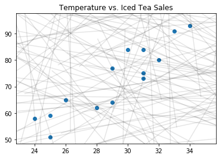

```python
plt.show()
```

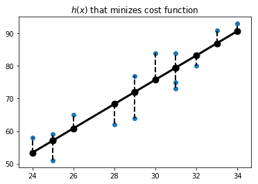

```python
plt.show()
```

## 氣溫與冰紅茶銷量（6）

- 先簡化成只有 $\theta_1$：

$$h(x) = \theta_1x_1$$

## 氣溫與冰紅茶銷量（7）

- 如果 $\theta_1 = 1$，即 $y = f(x) = x $
- 那麼我們在 $0 < \theta_1 < 2$ 之間打點來計算成本函數 $J(\theta_1)$

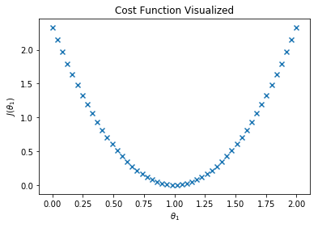

```python
import numpy as np
import matplotlib.pyplot as plt

def cost_function(theta_1, x, y):
    return np.sum((theta_1 * x - y)**2)/(2*len(x))

x = np.arange(1, 4)
y = x
theta_1_arr = np.linspace(0, 2, 50)
cost_arr = []
for i in theta_1_arr:
    cost_arr.append(cost_function(i, x, y))
plt.scatter(theta_1_arr, cost_arr, marker = 'x')
plt.xlabel("$\\theta_1$")
plt.ylabel("$J(\\theta_1)$")
plt.title("Cost Function Visualized")
plt.show()
```

## 氣溫與冰紅茶銷量（8）

- 假如我們的運氣不好，在一個沒有包含真實 $\theta_1$ 的區間尋找怎麼辦？

## 氣溫與冰紅茶銷量（9）

- 勢必要透過很聰明的方式找到 $\theta_1$ 完成任務：**Gradient Descent**

> 每組 $\theta_1$ 所得的成本函數偏微分取得斜率，利用這個斜率逐步取得局部最佳解。

## 氣溫與冰紅茶銷量（10）

- Gradient Descent

$$\theta_1 := \theta_1 - \alpha \frac{\mathrm \partial}{\mathrm \partial \theta_1} J(\theta_1)$$

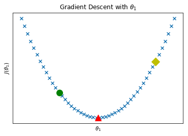

```python
plt.show()
```

## 氣溫與冰紅茶銷量（11）

- 梯度遞減（Gradient Descent）
  - $\theta_1 = 0.5$ 的時候（綠圓點），$\frac{\mathrm \partial}{\mathrm \partial \theta_1} J(\theta_1)$ 為負值，所以 $\theta_1$ 會向右邊修正
  - $\theta_1 = 1.75$ 的時候（黃方塊），$\frac{\mathrm \partial}{\mathrm \partial \theta_1} J(\theta_1)$ 為正值，所以 $\theta_1$ 會向左邊修正
  - $\theta_1 = 1.0$ 的時候（紅三角），$\frac{\mathrm \partial}{\mathrm \partial \theta_1} J(\theta_1)$ 為零，$\theta_1$ 收斂

## 氣溫與冰紅茶銷量（12）

- $\theta_1$ 修正的速度與 $\alpha$ 相關
  - $\alpha$ 稱為學習速率

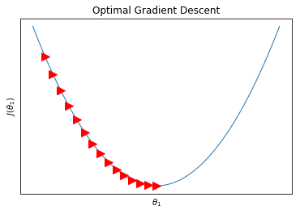

```python
plt.show()
```

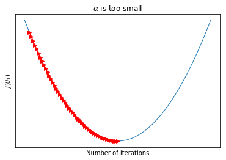

```python
plt.show()
```

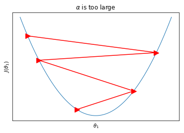

```python
plt.show()
```

## 氣溫與冰紅茶銷量（13）

- 如果學習速率夠小，成本函數每一次都會下降
- 學習速率太小，收斂的速度太慢
- 學習速率太大，可能會無法收斂

## 氣溫與冰紅茶銷量（14）

- 如果有 $(\theta_0, \theta_1)$：

$$h(x) = \theta_0 + \theta_1x_1$$$$\theta_0 := \theta_0 - \alpha \frac{\mathrm \partial}{\mathrm \partial \theta_0} J(\theta_0)$$$$\theta_1 := \theta_1 - \alpha \frac{\mathrm \partial}{\mathrm \partial \theta_1} J(\theta_1)$$

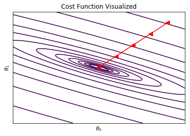

```python
plt.show()
```

## 氣溫與冰紅茶銷量（15）

- $x_i$ 的個數增加，表示用更多的特徵（features）來建立 $h$：

$$h(x) = \theta_0 + \theta_1 x_1 + \theta_2 x_2 + ... + \theta_n x_n$$

- 假如我們令 $x_0 = 1$，就可以將式子廣義地表示為：

$$h(x) = \begin{bmatrix} \theta_0 & \theta_1 & ... & \theta_n \end{bmatrix} \begin{bmatrix} x_0 \\ x_1 \\.\\.\\.\\ x_n \end{bmatrix} = \theta^{T}x$$

## 氣溫與冰紅茶銷量（16）

- 在梯度遞減的時候，每次迭代會**同時**更新所有的 $\theta_j$

$$\theta_j := \theta_j - \alpha \frac{\mathrm \partial}{\mathrm \partial \theta_j}J(\theta) \text{ }\text{ }\text{ }\text{ }for\text{ } j = 0 \text{ }...\text{ }n$$

## 氣溫與冰紅茶銷量（17）

- 請 Scikit-Learn 幫我們完成任務：
  - 找到一組 $(\theta_0, \theta_1)$ 讓成本函數最小化

## 氣溫與冰紅茶銷量（18）

- 訓練（train）與測試樣本（test）：
  - 訓練樣本用來建立 $h(x)$
  - 將測試樣本投入 $h(x)$ 建立預測 $\hat{y}$
  - 比對測試樣本的 $y$ 與 $\hat{y}$ 來評估 $h(x)$

```
from sklearn.model_selection import train_test_split
```

```python
import numpy as np
from sklearn import linear_model
from sklearn.model_selection import train_test_split

temperature = np.array([29, 28, 34, 31, 25, 29, 32, 31, 24, 33, 25, 31, 26, 30]).reshape(-1, 1)
iced_tea_sales = np.array([77, 62, 93, 84, 59, 64, 80, 75, 58, 91, 51, 73, 65, 84]).reshape(-1, 1)
X_train, X_test, y_train, y_test = train_test_split(temperature, iced_tea_sales, test_size = 0.3, random_state = 123)
reg = linear_model.LinearRegression()
reg.fit(X_train, y_train)
print("theta_0:%.4f" % reg.intercept_)
print("theta_1:%.4f" % reg.coef_)
```

```
theta_0:-28.8235
theta_1:3.5294
```

## 氣溫與冰紅茶銷量（19）

評估迴歸模型的指標：

- RMSE（愈低愈好）

$$RMSE = \sqrt{\frac{1}{N}\sum_{i=1}^N(\hat{y_i} - y_i) ^ 2}$$

- R-squared（愈接近 1 愈好）

$$R^2 = 1 - \frac{SSE}{SST} = 1 - \frac{\frac{1}{n}\sum_{i=1}^N(\hat{y_i} - y_i)^2}{\frac{1}{n}\sum_{i=1}^N(y_i - \mu)^2} = 1 - \frac{MSE}{Var(y)}$$

```python
from sklearn.metrics import mean_squared_error, r2_score

y_hat = reg.predict(X_test)
rmse = np.sqrt(mean_squared_error(y_test, y_hat))
print("R^2: %.4f" % r2_score(y_test, y_hat))
print("RMSE: %.4f" % rmse)
```

```
R^2: 0.5700
RMSE: 6.4033
```

## 氣溫與冰紅茶銷量（20）

- 試試看一個有二次項的 $h(x) = \theta_0 + \theta_1x_1 + \theta_2x_1^2$

```
from sklearn.preprocessing import PolynomialFeatures
```

```python
from sklearn.preprocessing import PolynomialFeatures
from sklearn import linear_model

temperature = np.array([29, 28, 34, 31, 25, 29, 32, 31, 24, 33, 25, 31, 26, 30]).reshape(-1, 1)
iced_tea_sales = np.array([77, 62, 93, 84, 59, 64, 80, 75, 58, 91, 51, 73, 65, 84]).reshape(-1, 1)
X_train, X_test, y_train, y_test = train_test_split(temperature, iced_tea_sales, test_size = 0.3, random_state = 42)
lr = linear_model.LinearRegression()
pr_q = linear_model.LinearRegression()

# create quadratic terms
quadratic = PolynomialFeatures(degree = 2)
X_train_quad = quadratic.fit_transform(X_train)

# fit linear model
lr.fit(X_train, y_train)
X_fit = np.linspace(min(X_train) * 0.8, max(X_train) * 1.2, 50).reshape(-1, 1)
y_lin_fit = lr.predict(X_fit)

# fit quadratic model
pr_q.fit(X_train_quad, y_train)
y_quad_fit = pr_q.predict(quadratic.fit_transform(X_fit))
```

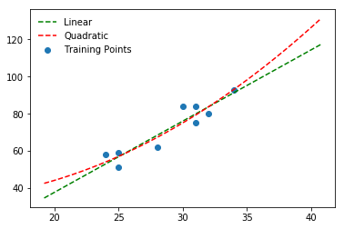

```python
import matplotlib.pyplot as plt

# plotting
plt.scatter(X_train, y_train, label = "Training Points")
plt.plot(X_fit, y_lin_fit, label = "Linear", linestyle = "--", c = "g")
plt.plot(X_fit, y_quad_fit, label = "Quadratic", c = "r", linestyle = "--")
plt.legend(loc = "upper left", frameon = False)
plt.show()
```

```python
from sklearn.metrics import mean_squared_error, r2_score

y_lin_hat = lr.predict(X_test)
y_quad_hat = pr_q.predict(quadratic.fit_transform(X_test))
rmse_lin = np.sqrt(mean_squared_error(y_test, y_lin_hat))
rmse_quad = np.sqrt(mean_squared_error(y_test, y_quad_hat))
print("RMSE: \n Linear: %.4f \n Quadratic: %.4f" % (rmse_lin, rmse_quad))
print("\n")
r_2_lin = r2_score(y_test, y_lin_hat)
r_2_quad = r2_score(y_test, y_quad_hat)
print("R^2: \n Linear: %.4f \n Quadratic: %.4f" % (r_2_lin, r_2_quad))
```

```
RMSE:
 Linear: 5.7960
 Quadratic: 5.5555


R^2:
 Linear: 0.6501
 Quadratic: 0.6785
```